# Summary of the fitted operating models

ABT-MSE

Tom Carruthers

February 15, 2019

# 1 Introduction / notes

This is a report of various M vectors from CCSBT.

Base: (ages 25-35+) = 0.1 0.1 0.1 0.1 0.1 0.1 0.1 0.1 0.1 0.1 0.1

SBT_L: (ages 25-35+) = 0.1 0.12 0.14 0.16 0.18 0.2 0.2 0.2 0.2 0.2 0.2

SBT_M: (ages 25-35+) = 0.1 0.155 0.21 0.265 0.32 0.375 0.375 0.375 0.375 0.375 0.375

SBT_H: (ages 25-35+) = 0.1 0.19 0.28 0.37 0.46 0.55 0.55 0.55 0.55 0.55 0.55

# 2 OM design

# 3 OMs presented in this report

Table 1. The subset of wider operating models included in this comparison report.

| OM |
| --- |
| Base |
| SBT_L |
| SBT_M |
| SBT_H |

# 4 Residuals in indices

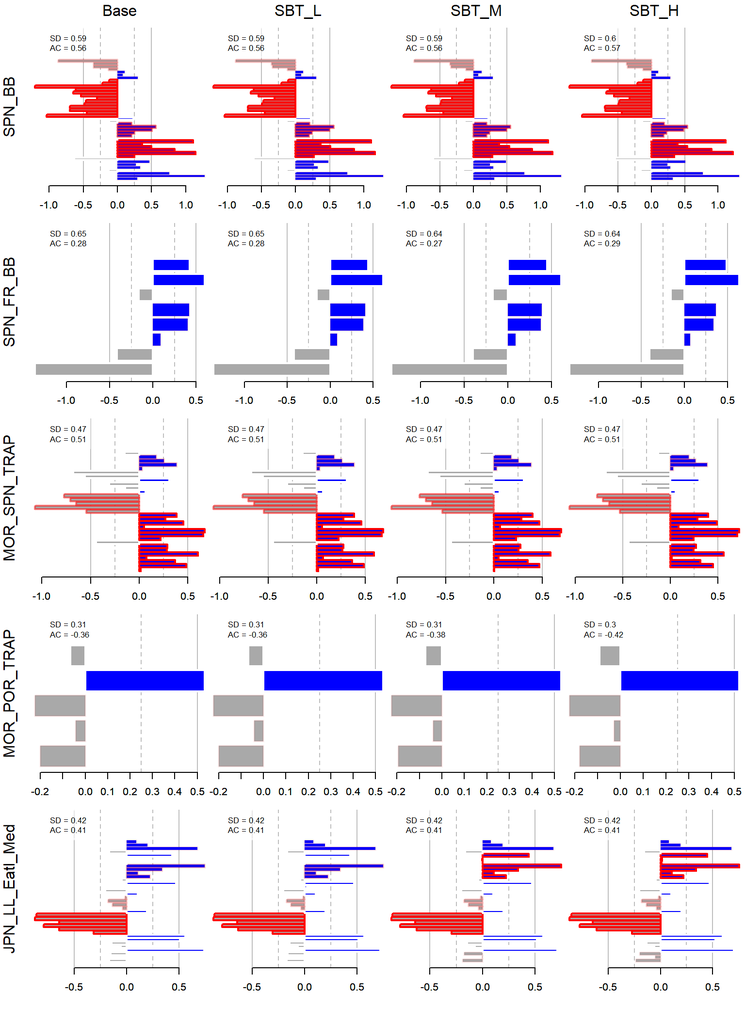

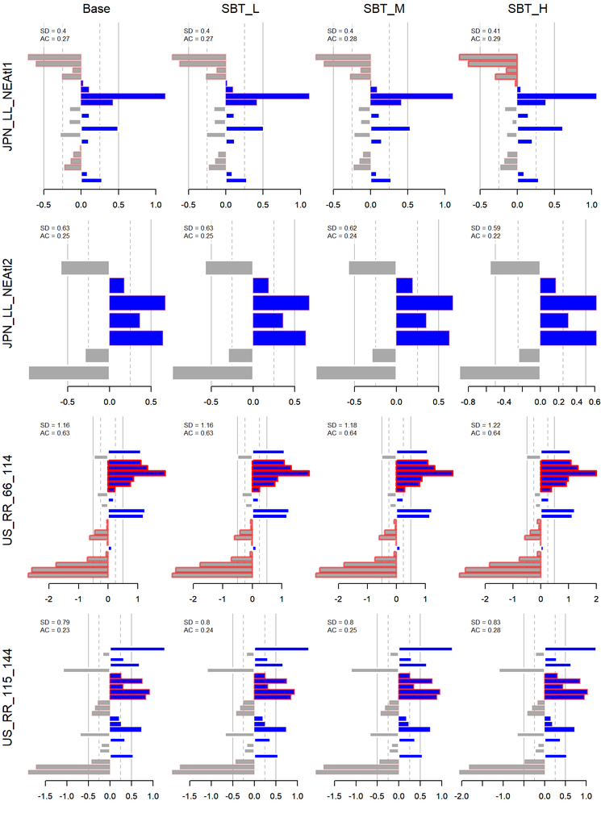

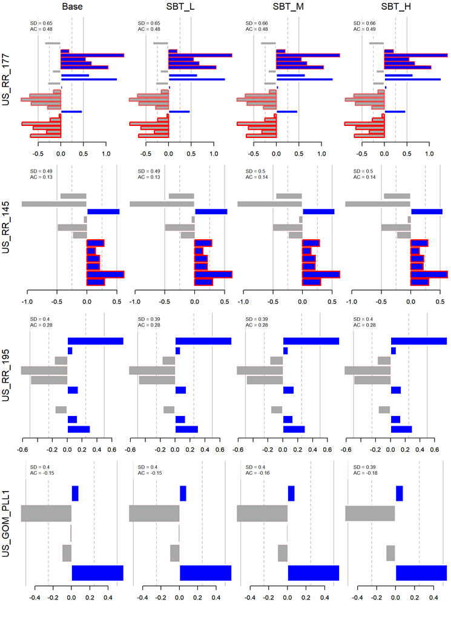

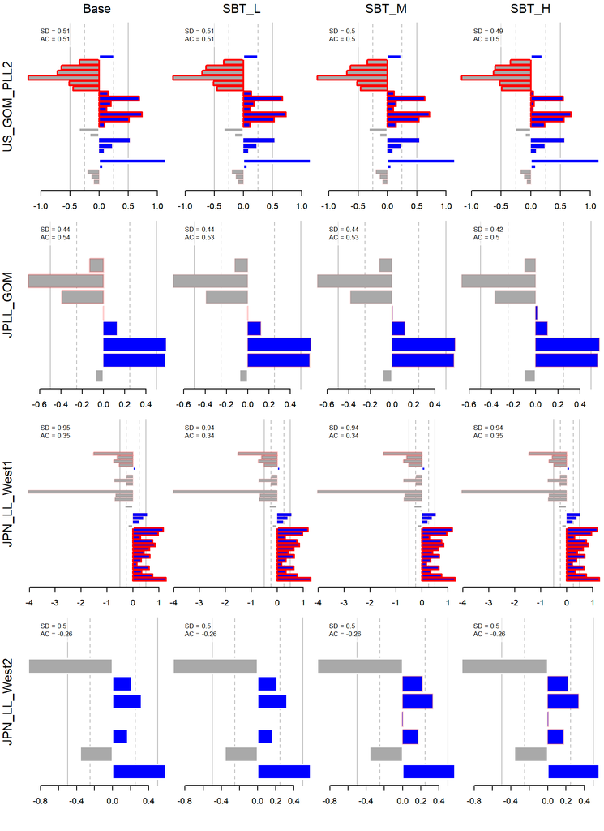

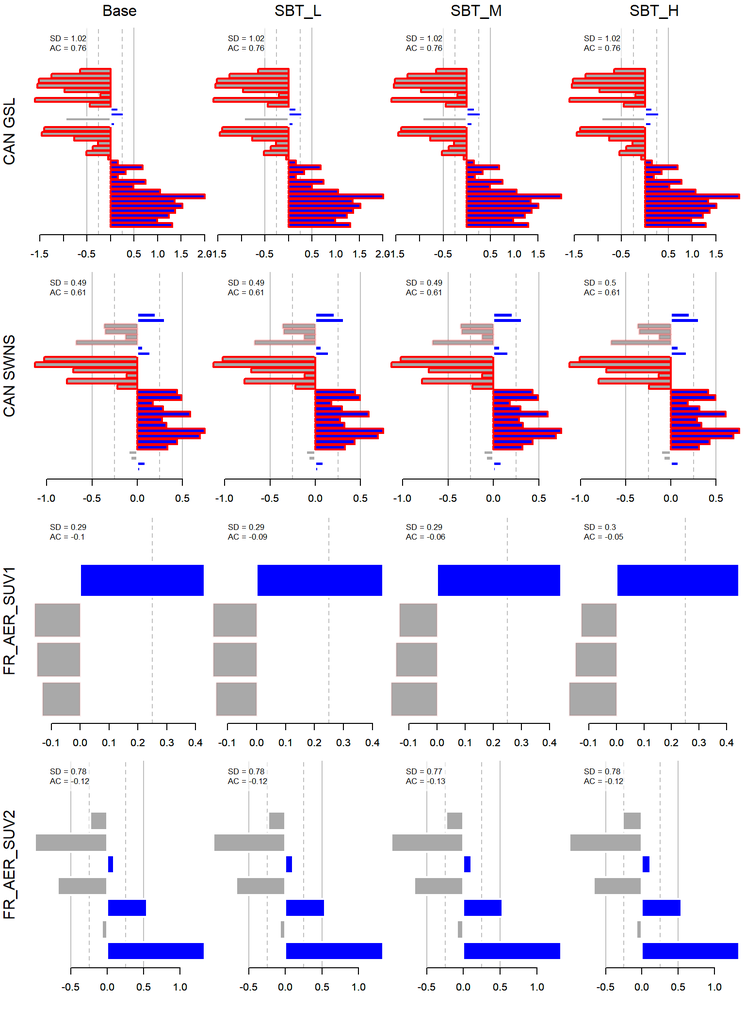

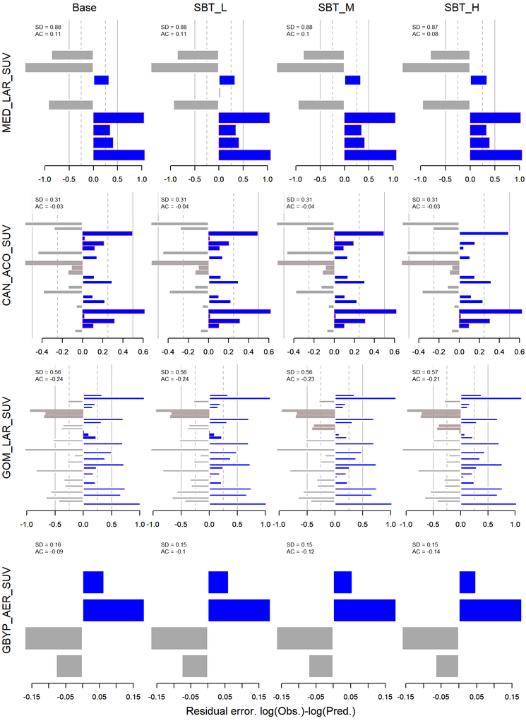

# 5 Spawning stock biomass trends by stock and area

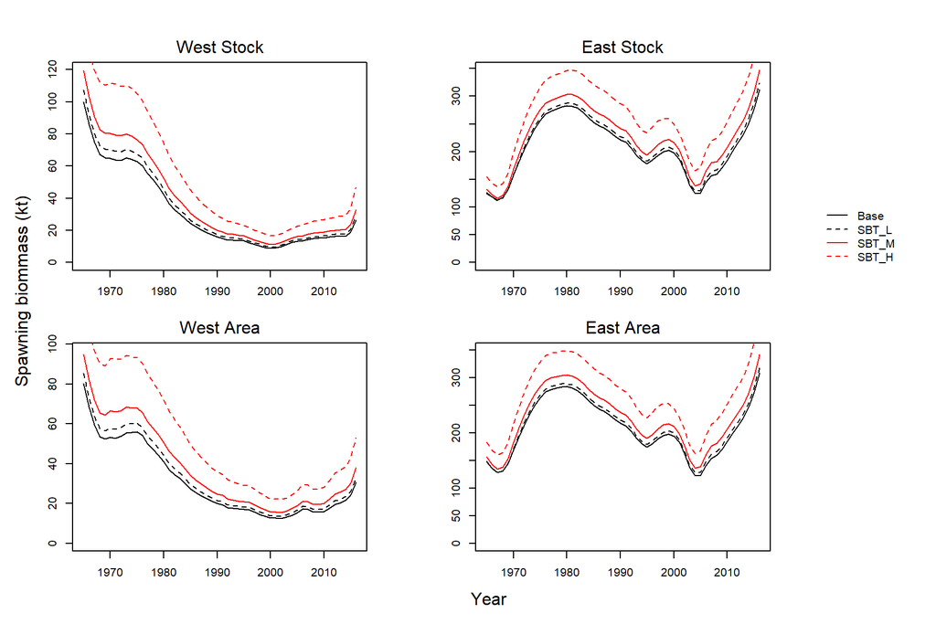

# 6 Model estimates / reference points

## 6.1 Eastern stock

Table 1. Reference points for the Eastern stock using 2015 stock-recruitment (R0 and steepness). FMSY refers to apical F (the instantaneous fishing mortality rate on the most selected length class). UMSY is current yield divided by vulnerable biomass. Tabulated biomass numbers (BMSY, BMSY_B0 and B2015) refer to spawning biomass. These biomass numbers and MSY numbers are expressed in thousands of tonnes. Depletion is spawning biomass in 2015 relative to the ‘dynamic B0’ (the spawning biomass under zero fishing accounting for shifts in recruitment).

| OM | Code | MSY | FMSY | BMSY | BMSY_B0 | F_FMSY | B_BMSY | Dep |
| --- | --- | --- | --- | --- | --- | --- | --- | --- |
| Base | Base | 49429 | 0.673 | 568579 | 0.361 | 0.591 | 0.55 | 0.232 |
| SBT_L | SBT_L | 50031 | 0.691 | 553675 | 0.373 | 0.558 | 0.584 | 0.255 |
| SBT_M | SBT_M | 51046 | 0.72 | 564251 | 0.388 | 0.517 | 0.615 | 0.278 |
| SBT_H | SBT_H | 53283 | 0.795 | 593560 | 0.397 | 0.408 | 0.707 | 0.327 |

## 6.2 Western stock

Table 2. As Table 1 but for the Western stock.

| OM | Code | MSY | FMSY | BMSY | BMSY_B0 | F_FMSY | B_BMSY | Dep |
| --- | --- | --- | --- | --- | --- | --- | --- | --- |
| Base | Base | 3309 | 0.121 | 42528 | 0.305 | 1.547 | 0.624 | 0.22 |
| SBT_L | SBT_L | 3323 | 0.123 | 37949 | 0.308 | 1.402 | 0.757 | 0.27 |
| SBT_M | SBT_M | 3395 | 0.125 | 37290 | 0.311 | 1.199 | 0.879 | 0.316 |
| SBT_H | SBT_H | 3703 | 0.13 | 39572 | 0.311 | 0.772 | 1.177 | 0.425 |

# 7 SSB trends by stock

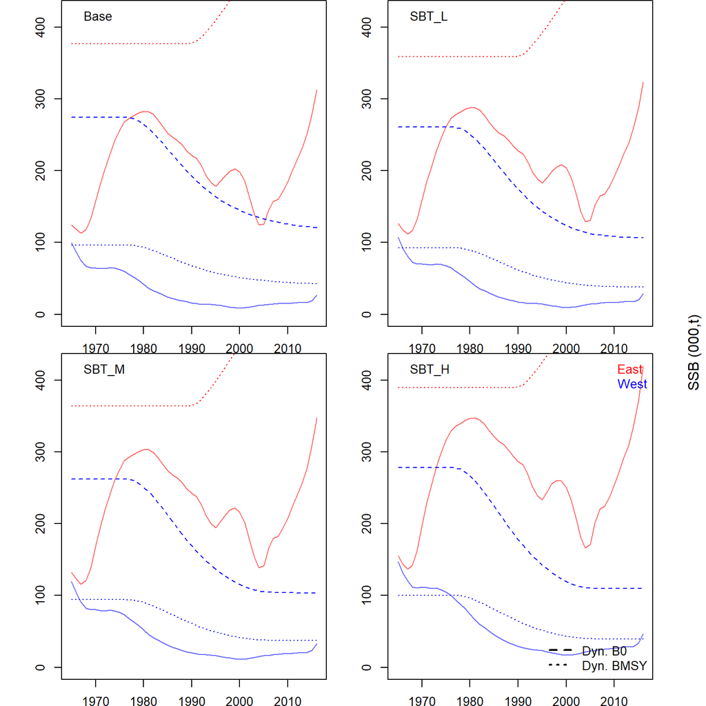

# 8 Negative log-likelihood components

Table 3. Contribution of negative log-likelihood components (lower values are better fit) to global objective function. Each likelihood component has a specific weighting that is documented in the trial specifications.

| OM | Code | Catch | CPUE | Survey | L Comp | SOO | PSAT | Rec Dev | Mov Pr | Sel Pr | SRA pen | SSB Pr | Dep Pr | MI Pr | TOT |
| --- | --- | --- | --- | --- | --- | --- | --- | --- | --- | --- | --- | --- | --- | --- | --- |
| 4 | Base | 2777.0 | 19.3 | 246.2 | 87.1 | 1483.0 | 774.0 | 62.1 | 3.1 | 1 | 0.3 | 0 | 0 | 46.7 | 5526.7 |
| 1 | SBT_L | 2776.6 | 19.3 | 246.9 | 88.6 | 1485.0 | 773.4 | 63.9 | 3.1 | 1 | 0.2 | 0 | 0 | 46.2 | 5532.0 |
| 2 | SBT_M | 2773.8 | 19.4 | 248.7 | 88.8 | 1487.5 | 773.0 | 67.2 | 3.2 | 1 | 0.4 | 0 | 0 | 45.4 | 5536.9 |
| 3 | SBT_H | 2769.1 | 19.8 | 252.8 | 85.4 | 1488.1 | 769.8 | 73.4 | 3.4 | 1 | 0.2 | 0 | 0 | 45.6 | 5536.8 |

Catch = catch data by fleet, quarter and area. CPUE = the fishery dependent CPUE indices, Survey = fishery-independent indices, L Comp = length composition data, SOO = stock of origin data, PSAT = Electronic tagging data, Rec Dev = prior on recruitment deviations, Mov Pr = prior on movement parameters, Sel Pr = prior on size selectivity parameters, SRA pen = penalty incurred when catches exceed F=1 catches in the stock reduction analysis phase (1864-1964), SSB Pr = a prior on spawning stock biomass by area for reference operating models B (match VPA assessments), Dep Pr = a prior on stock depletion since 1980 to generate more depleted stocks for refernece operating models C (historically low stock levels), MI Pr = a prior on similarlity to the ‘Master Index’ that predicts F by year, area, season and fleet, TOT = total global objective function.